# Blog Advertising Analysis through EDA

Mark Ngendo

7/2/2021

## Specifying the Question

A Kenyan entrepreneur has created an online cryptography course and would want to advertise it on her blog. She currently targets audiences originating from various countries. In the past, she ran ads to advertise a related course on the same blog and collected data in the process. She would now like to employ your services as a Data Science Consultant to help her identify which individuals are most likely to click on her ads.

## Understanding the Context

Digital marketing has become increasingly popular as more and more business shift towards targeting their clients using the internet. As every business rushes to grab its share of online consumers, the question of what is behind a successful ad becomes increasingly important. Some factors have stood out such as:

- Whether the ad is in text form or not
- Relevance to what the users were searching for
- Whether the users fit the relevant demographic of the ad
- Which websites they use when searching online

## Defining the metric of Success

The study will be considered a success if it can identify which people are likely to click on the clients advertisements given the features available in the data.

## Recording the experimental design

- Loading the data
- Performing Data Cleaning
- Perform Exploratory Data Analysis:
  - Uni variate and,
  - Bi variate analysis
- Provide Insights from analysis
- Solution implementation using Supervised Modeling
- Provide Recommendations based on insights

## Data Relevance

The data set can be gotten from this [Link](http://bit.ly/IPAdvertisingData) Below is the glossary:

- Daily time spent - Specifies how many minutes an individual spends on site in a day
- Age - Age of the individual
- Area Income
- Daily Internet Usage - total minutes spent on the internet by the individual
- Ad Topic Line - title of the Ad presented to the Individual
- City - City the individual resides in
- Male - Binary (0: Female/Not Male, 1: Male)
- Country - Country the individual resides in
- Time stamp
- Clicked on Ad - Binary(0: No, 1: Yes)

## Objectives

### Overall Objectives

To identify the individuals that are most likely to click on the client’s ads

### Specific Objectives

- To identify the blog’s key demographic in terms of age group, gender and country of origin.
- To examine the relationship between time spent on the blog and daily internet usage when it comes to clicking on ads.

## Loading the Libraries

```r
library(data.table)
library(tidyverse)
```

```r
library(ggplot2)
library(e1071)
library(gridExtra)
library(dplyr)
library(rpart)
library(rpart.plot)
library(ranger)
library(caret)
library(modelr)
library(broom)
```

## Loading the dataset

Previewing the top of the dataset

```r
df <- read.csv(("http://bit.ly/IPAdvertisingData"))
head(df)
```

```
##   Daily.Time.Spent.on.Site Age Area.Income Daily.Internet.Usage
## 1                    68.95  35    61833.90               256.09
## 2                    80.23  31    68441.85               193.77
## 3                    69.47  26    59785.94               236.50
## 4                    74.15  29    54806.18               245.89
## 5                    68.37  35    73889.99               225.58
## 6                    59.99  23    59761.56               226.74
##                           Ad.Topic.Line           City Male    Country
## 1    Cloned 5thgeneration orchestration    Wrightburgh    0    Tunisia
## 2    Monitored national standardization      West Jodi    1      Nauru
## 3      Organic bottom-line service-desk       Davidton    0 San Marino
## 4 Triple-buffered reciprocal time-frame West Terrifurt    1      Italy
## 5         Robust logistical utilization   South Manuel    0    Iceland
## 6       Sharable client-driven software      Jamieberg    1     Norway
##             Timestamp Clicked.on.Ad
## 1 2016-03-27 00:53:11             0
## 2 2016-04-04 01:39:02             0
## 3 2016-03-13 20:35:42             0
## 4 2016-01-10 02:31:19             0
## 5 2016-06-03 03:36:18             0
## 6 2016-05-19 14:30:17             0
```

Previewing the tail of the dataset

```r
tail(df)
```

```
##      Daily.Time.Spent.on.Site Age Area.Income Daily.Internet.Usage
## 995                     43.70  28    63126.96               173.01
## 996                     72.97  30    71384.57               208.58
## 997                     51.30  45    67782.17               134.42
## 998                     51.63  51    42415.72               120.37
## 999                     55.55  19    41920.79               187.95
## 1000                    45.01  26    29875.80               178.35
##                             Ad.Topic.Line          City Male
## 995         Front-line bifurcated ability  Nicholasland    0
## 996         Fundamental modular algorithm     Duffystad    1
## 997       Grass-roots cohesive monitoring   New Darlene    1
## 998          Expanded intangible solution South Jessica    1
## 999  Proactive bandwidth-monitored policy   West Steven    0
## 1000      Virtual 5thgeneration emulation   Ronniemouth    0
##                     Country           Timestamp Clicked.on.Ad
## 995                 Mayotte 2016-04-04 03:57:48             1
## 996                 Lebanon 2016-02-11 21:49:00             1
## 997  Bosnia and Herzegovina 2016-04-22 02:07:01             1
## 998                Mongolia 2016-02-01 17:24:57             1
## 999               Guatemala 2016-03-24 02:35:54             0
## 1000                 Brazil 2016-06-03 21:43:21             1
```

```r
# viewing the structure of the data

str(df)
```

```
## 'data.frame':    1000 obs. of  10 variables:
##  $ Daily.Time.Spent.on.Site: num  69 80.2 69.5 74.2 68.4 ...
##  $ Age                     : int  35 31 26 29 35 23 33 48 30 20 ...
##  $ Area.Income             : num  61834 68442 59786 54806 73890 ...
##  $ Daily.Internet.Usage    : num  256 194 236 246 226 ...
##  $ Ad.Topic.Line           : chr  "Cloned 5thgeneration orchestration" "Monitored national standardization" "Organic bottom-line service-desk" "Triple-buffered reciprocal time-frame" ...
##  $ City                    : chr  "Wrightburgh" "West Jodi" "Davidton" "West Terrifurt" ...
##  $ Male                    : int  0 1 0 1 0 1 0 1 1 1 ...
##  $ Country                 : chr  "Tunisia" "Nauru" "San Marino" "Italy" ...
##  $ Timestamp               : chr  "2016-03-27 00:53:11" "2016-04-04 01:39:02" "2016-03-13 20:35:42" "2016-01-10 02:31:19" ...
##  $ Clicked.on.Ad           : int  0 0 0 0 0 0 0 1 0 0 ...
```

## Data Cleaning

### Completeness

Checking for Null values

```r
colSums(is.na(df))
```

```
## Daily.Time.Spent.on.Site                      Age              Area.Income
##                        0                        0                        0
##     Daily.Internet.Usage            Ad.Topic.Line                     City
##                        0                        0                        0
##                     Male                  Country                Timestamp
##                        0                        0                        0
##            Clicked.on.Ad
##                        0
```

### Consistency

Checking for duplicates

```r
df[duplicated(df), ]
```

```
##  [1] Daily.Time.Spent.on.Site Age                      Area.Income
##  [4] Daily.Internet.Usage     Ad.Topic.Line            City
##  [7] Male                     Country                  Timestamp
## [10] Clicked.on.Ad
## <0 rows> (or 0-length row.names)
```

### Accuracy

```r
# casting Male and Clicked on ad as categorical columns

df$Male <- as.factor(df$Male)
df$Clicked.on.Ad <- as.factor(df$Clicked.on.Ad)

# confirming

str(df$Clicked.on.Ad)
```

```
##  Factor w/ 2 levels "0","1": 1 1 1 1 1 1 1 2 1 1 ...
```

```r
str(df$Male)
```

```
##  Factor w/ 2 levels "0","1": 1 2 1 2 1 2 1 2 2 2 ...
```

## Univariate Analysis

### Daily Time Spent on Site

```r
# Mean
site_time.mean <- mean(df$Daily.Time.Spent.on.Site)
site_time.mean
```

```
## [1] 65.0002
```

```r
# mode
get_mode <- function(x){
  uniqx <- unique(x)
  uniqx[which.max(tabulate(match(x, uniqx)))]
}

site_time.mode <- get_mode(df$Daily.Time.Spent.on.Site)
site_time.mode
```

```
## [1] 62.26
```

```r
# Median
site_time.median <- median(df$Daily.Time.Spent.on.Site)
site_time.median
```

```
## [1] 68.215
```

```r
# Standard Deviation

site_time.sd <- sd(df$Daily.Time.Spent.on.Site)
site_time.sd
```

```
## [1] 15.85361
```

```r
# Skewness
site_time.skew <- skewness(df$Daily.Time.Spent.on.Site)
site_time.skew
```

```
## [1] -0.370646
```

```r
# Kurtosis
site_time.kurt <- kurtosis(df$Daily.Time.Spent.on.Site)
site_time.kurt
```

```
## [1] -1.099864
```

```r
# Quantiles
site_time.quantiles <- quantile(df$Daily.Time.Spent.on.Site)
site_time.quantiles
```

```
##      0%     25%     50%     75%    100%
## 32.6000 51.3600 68.2150 78.5475 91.4300
```

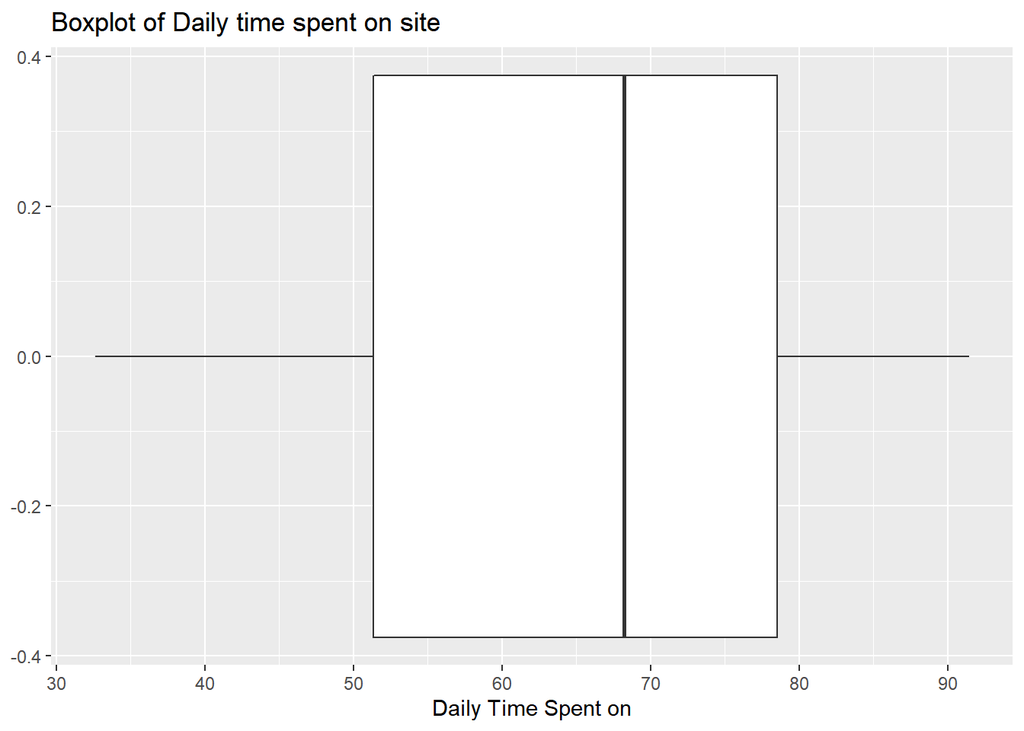

```r
# Boxplot
ggplot(df, aes(x=Daily.Time.Spent.on.Site)) +
  geom_boxplot(outlier.colour = 'red') +
  labs(title='Boxplot of Daily time spent on site',
       x='Daily Time Spent on')
```

### Age

```r
age.mean <- mean(df$Age)
age.mean
```

```
## [1] 36.009
```

```r
# Mode
age.mode <- get_mode(df$Age)
age.mode
```

```
## [1] 31
```

```r
# Median
age.median <- median(df$Age)
age.median
```

```
## [1] 35
```

```r
# Standard Deviation
age.sd <- sd(df$Age)
age.sd
```

```
## [1] 8.785562
```

```r
# Kurtosis
age.kurt <- kurtosis(df$Age)
age.kurt
```

```
## [1] -0.4097066
```

```r
# Skewness
age.skew <- skewness(df$Age)
age.skew
```

```
## [1] 0.4777052
```

```r
# Quantiles
age.quantiles <- quantile(df$Age)
age.quantiles
```

```
##   0%  25%  50%  75% 100%
##   19   29   35   42   61
```

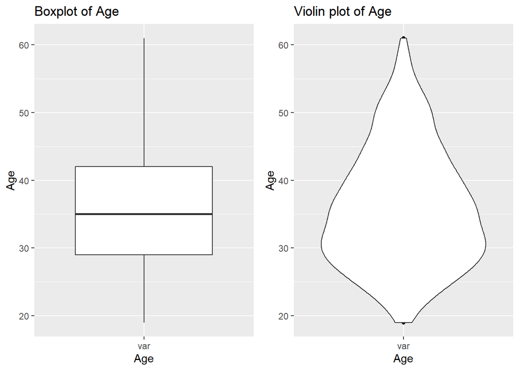

```r
# Boxplot
age1 <-ggplot(df, aes('var', Age)) +
    geom_boxplot(outlier.colour = 'red') +
    labs(title="Boxplot of Age",
        x="Age")
age2 <- ggplot(df, aes("var",Age)) +
  geom_point() +
  geom_violin() +

  labs(title="Violin plot of Age",
       x="Age")
grid.arrange(age1, age2, nrow=1)
```

### Area Income

```r
# Mean
income.mean <- mean(df$Area.Income)
income.mean
```

```
## [1] 55000
```

```r
# Mode
income.mode <- get_mode(df$Area.Income)
income.mode
```

```
## [1] 61833.9
```

```r
# Median
income.median <- median(df$Area.Income)
income.median
```

```
## [1] 57012.3
```

```r
# Quantiles
income.quantiles <- quantile(df$Area.Income)
income.quantiles
```

```
##       0%      25%      50%      75%     100%
## 13996.50 47031.80 57012.30 65470.64 79484.80
```

```r
# Standard Deviation
income.sd <- sd(df$Area.Income)
income.sd
```

```
## [1] 13414.63
```

```r
# Skewness
income.skew <- skewness(df$Area.Income)
income.skew
```

```
## [1] -0.6484229
```

```r
# Kurtosis
income.kurt <- kurtosis(df$Area.Income)
income.kurt
```

```
## [1] -0.1110924
```

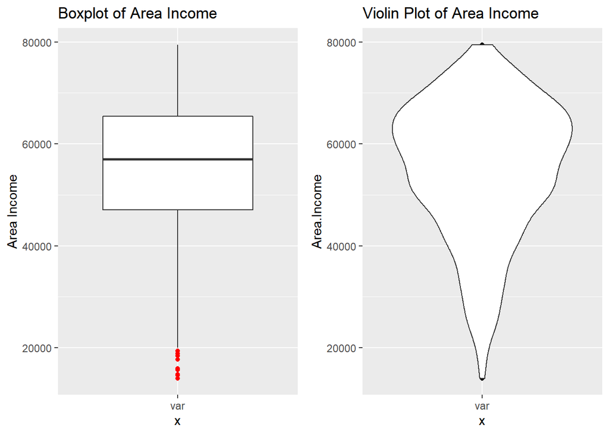

```r
# distribution
income1 <- ggplot(df, aes("var", Area.Income)) +
            geom_boxplot(outlier.colour = 'red') +
            labs(title="Boxplot of Area Income",
                 y="Area Income")
income2 <- ggplot(df, aes("var", Area.Income)) +
            geom_point() +
            geom_violin() +
            labs(title="Violin Plot of Area Income")
grid.arrange(income1, income2, ncol=2)
```

### Daily Internet Usage

```r
# Mean
net_time.mean <- mean(df$Daily.Internet.Usage)
net_time.mean
```

```
## [1] 180.0001
```

```r
# Mode
net_time.mode <- get_mode(df$Daily.Internet.Usage)
net_time.mode
```

```
## [1] 167.22
```

```r
# Median
net_time.median <- median(df$Daily.Internet.Usage)
net_time.median
```

```
## [1] 183.13
```

```r
# Quantiles
net_time.quantiles <- quantile(df$Daily.Internet.Usage)
net_time.quantiles
```

```
##       0%      25%      50%      75%     100%
## 104.7800 138.8300 183.1300 218.7925 269.9600
```

```r
# standard Deviation
net_time.sd <- sd(df$Daily.Internet.Usage)
net_time.sd
```

```
## [1] 43.90234
```

```r
# Kurtosis
net_time.kurt <- kurtosis(df$Daily.Internet.Usage)
net_time.kurt
```

```
## [1] -1.275752
```

```r
# Skewness
net_time.skew <- skewness(df$Daily.Internet.Usage)
net_time.skew
```

```
## [1] -0.03343681
```

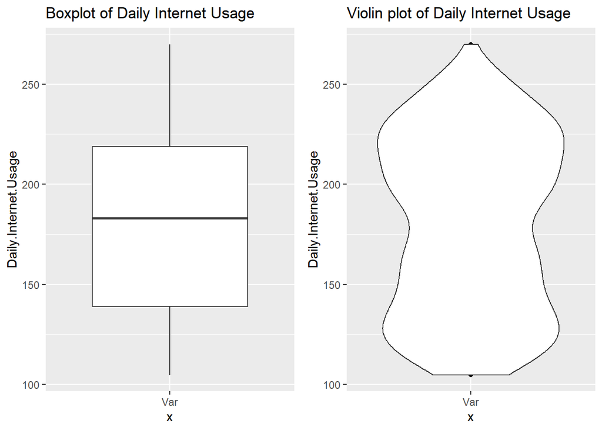

```r
# Distribution

netb <- ggplot(df, aes("Var", Daily.Internet.Usage)) +
        geom_boxplot(outlier.color = 'red') +
        labs(title="Boxplot of Daily Internet Usage")

netv <- ggplot(df, aes("Var", Daily.Internet.Usage)) +
        geom_point() +
        geom_violin() +
        labs(title="Violin plot of Daily Internet Usage")

grid.arrange(netb, netv, ncol=2)
```

### Plots of visualizations

Age distribution

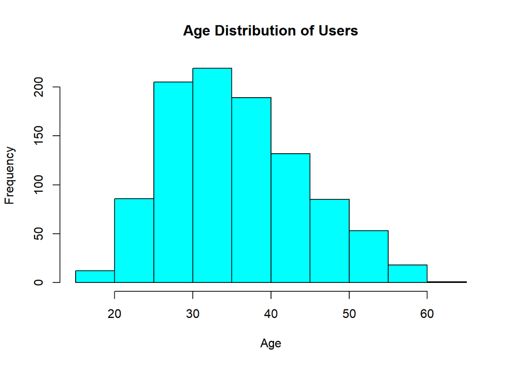

```r
hist(x= df$Age, xlab='Age', col="Cyan",
     main="Age Distribution of Users")
```

The plot shows that the majority of site visitors are between age 25 and 40.

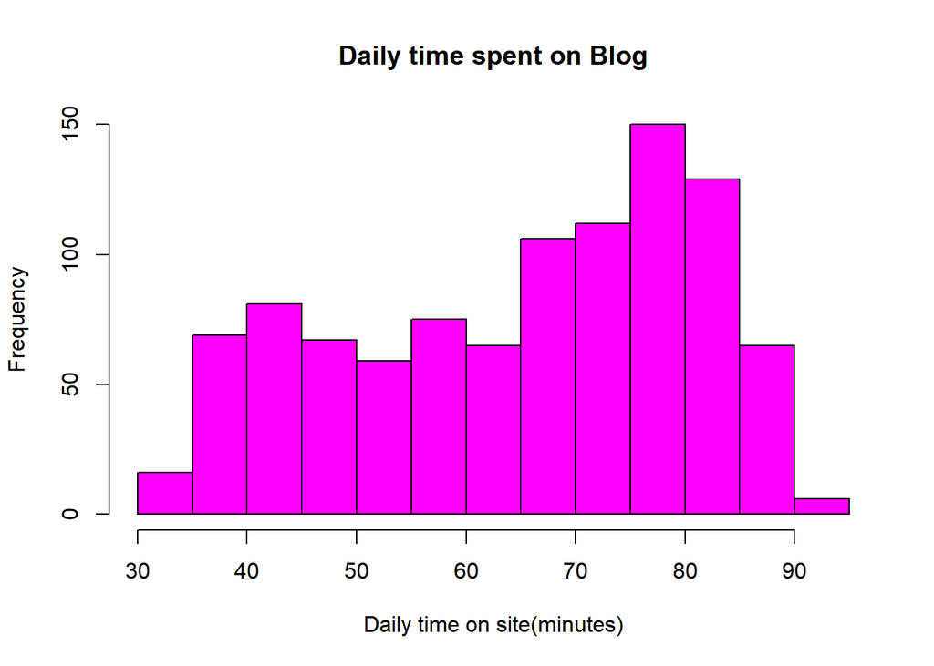

```r
hist(x=df$Daily.Time.Spent.on.Site, col="magenta", xlab="Daily time on site(minutes)",
     main = "Daily time spent on Blog")
```

From this, it is clear that quite a number of users spend an upward of 60 minutes on the blog’s website. It is mainly between 1-1 hour 20 minutes. Though, there are some who spend less than an hour on the site.

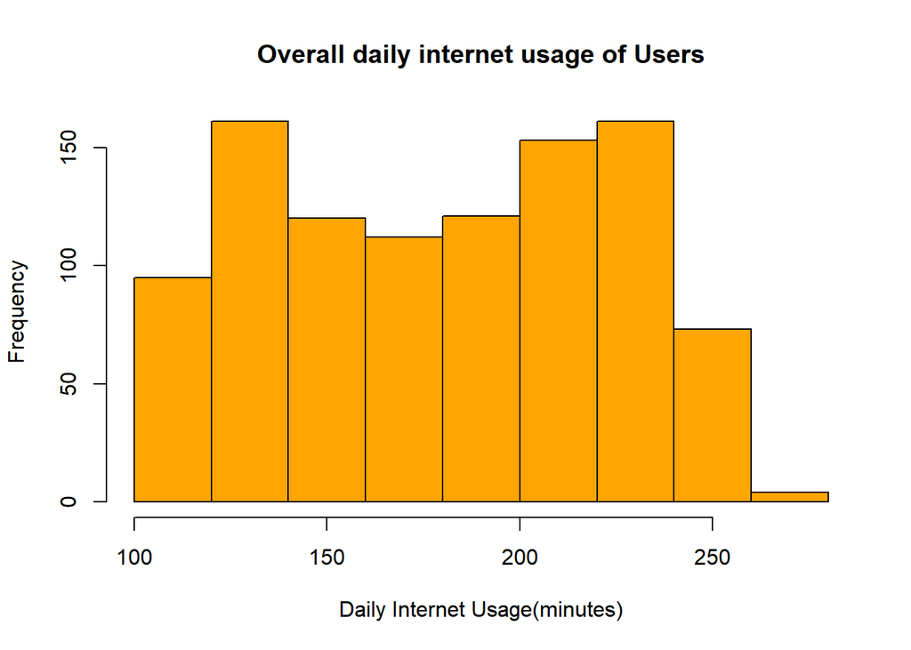

```r
hist(x=df$Daily.Internet.Usage, xlab="Daily Internet Usage(minutes)", col="orange",
     main="Overall daily internet usage of Users")
```

This graph shows that most users that visit the site spend roughly between 2 to 4 hours in total on the internet.

```r
table(df$Male)
```

```
##
##   0   1
## 519 481
```

The above frequency table shows that the site has more female/non-male(0) visitors than males(1).

```r
table(df$Clicked.on.Ad)
```

```
##
##   0   1
## 500 500
```

There were an equal number of users who clicked on ads as those who did not.

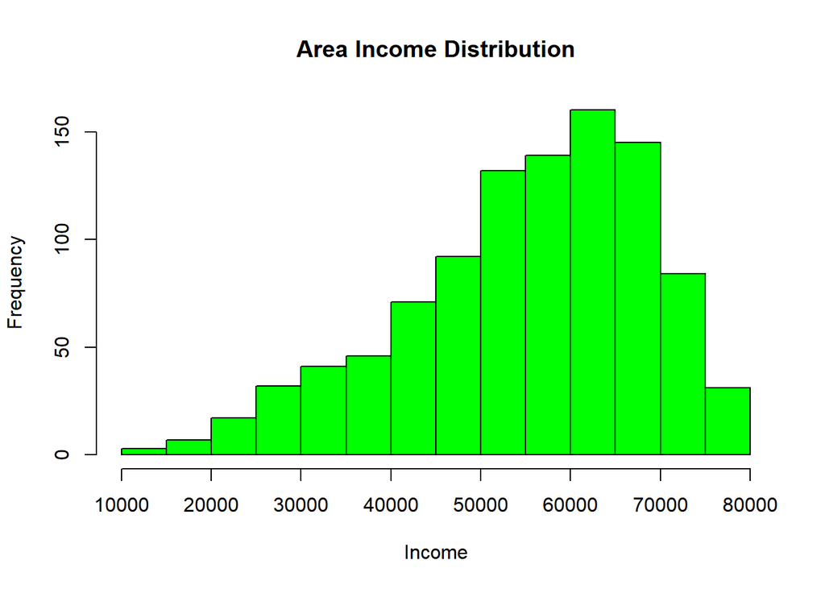

```r
# to inspect the area income distribution
hist(df$Area.Income, col="green", main='Area Income Distribution',
    xlab="Income")
```

### Bivariate Analaysis

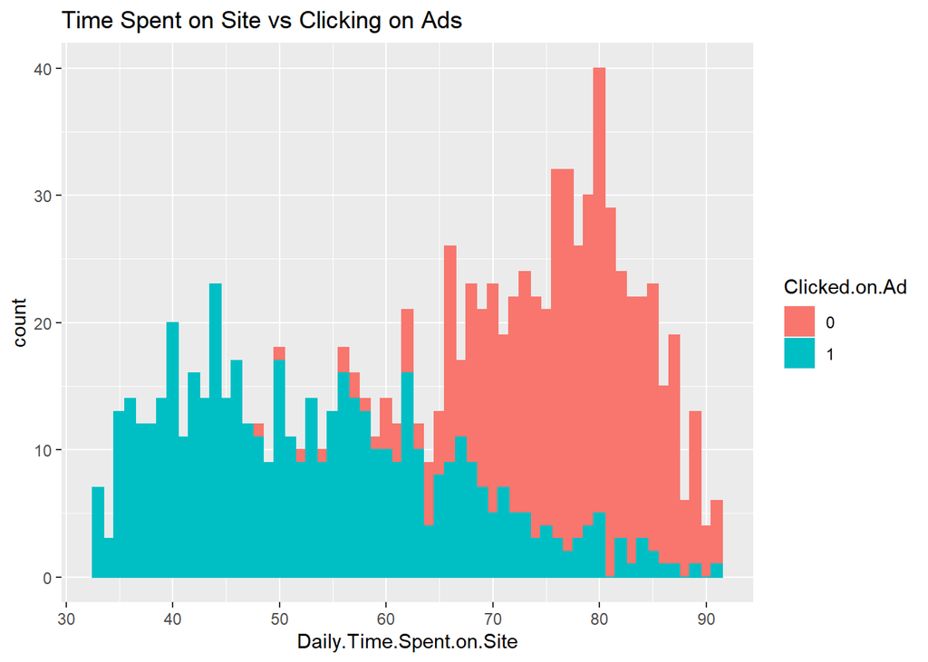

```r
# area income vs clicking on ads
ggplot(df, aes(x=Daily.Time.Spent.on.Site, fill=Clicked.on.Ad, color=Clicked.on.Ad)) +
  geom_histogram(binwidth=1) + labs(title="Time Spent on Site vs Clicking on Ads")
```

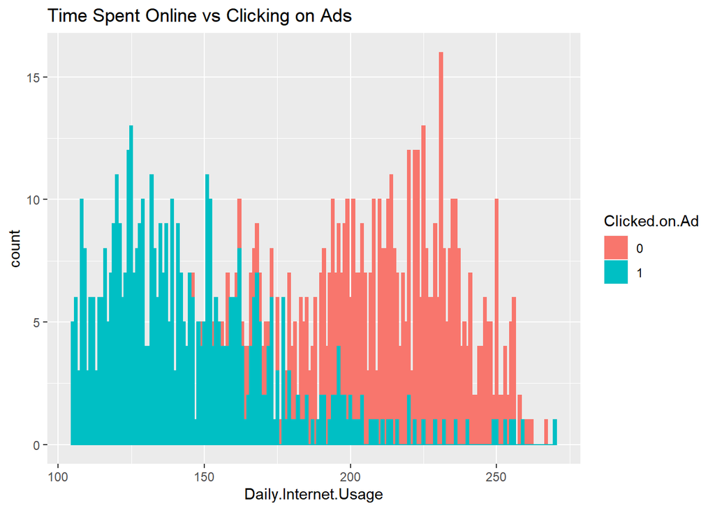

```r
ggplot(df, aes(x=Daily.Internet.Usage, fill=Clicked.on.Ad, color=Clicked.on.Ad)) +
  geom_histogram(binwidth=1) + labs(title="Time Spent Online vs Clicking on Ads")
```

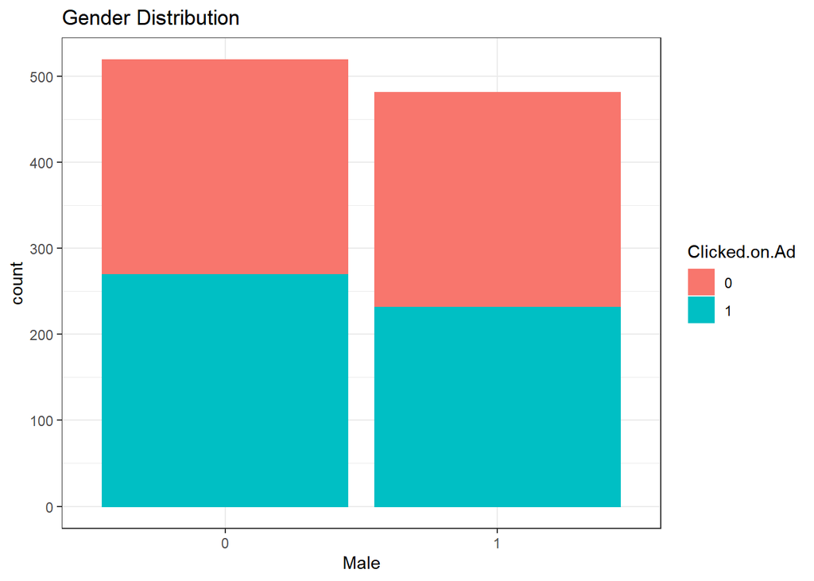

```r
# how each gender reacts to ads
ggplot(df, aes(x=Male, fill=Clicked.on.Ad, color=Clicked.on.Ad)) +
  geom_histogram(binwidth = 1, stat = "count") + labs(title="Gender Distribution") +
  theme_bw()
```

The non-male category seems to click on ads slightly more than their male counterparts.

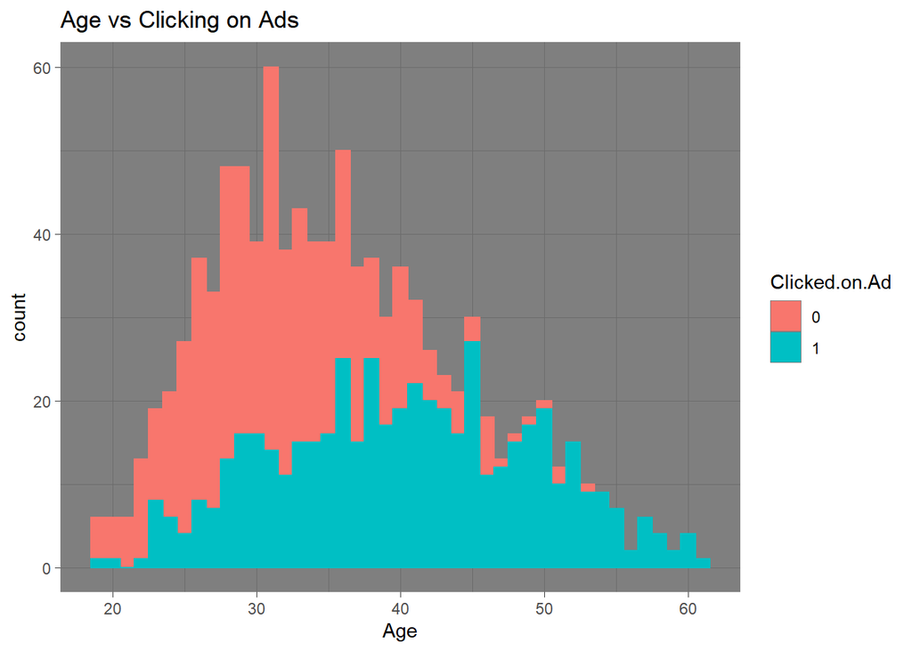

```r
# Age distribution and Ads

ggplot(data=df, aes(Age,fill=Clicked.on.Ad, color=Clicked.on.Ad)) +
  geom_histogram(binwidth=1) + labs(title="Age vs Clicking on Ads") +
  theme_dark()
```

Majority of the people aged between 20 and 40 tend not to click on ads on the site.

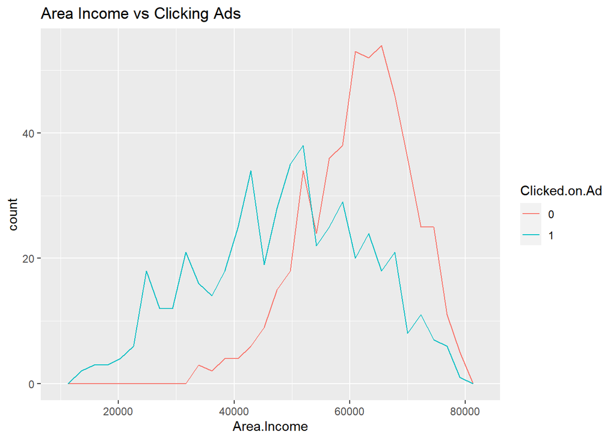

```r
# Area income vs Ads
ggplot(data=df, aes(Area.Income, color=Clicked.on.Ad)) +
  geom_freqpoly() +
  labs(title="Area Income vs Clicking Ads")
```

### Correlations

```r
cor(df[, c('Daily.Time.Spent.on.Site', "Daily.Internet.Usage", "Area.Income", "Age")])
```

```
##                          Daily.Time.Spent.on.Site Daily.Internet.Usage
## Daily.Time.Spent.on.Site                1.0000000            0.5186585
## Daily.Internet.Usage                    0.5186585            1.0000000
## Area.Income                             0.3109544            0.3374955
## Age                                    -0.3315133           -0.3672086
##                          Area.Income        Age
## Daily.Time.Spent.on.Site   0.3109544 -0.3315133
## Daily.Internet.Usage       0.3374955 -0.3672086
## Area.Income                1.0000000 -0.1826050
## Age                       -0.1826050  1.0000000
```

## Solution Implementation

```r
# choosing features to be used
x <- df[, c(1, 2, 3,4, 7, 10)]
y <- df[, "Clicked.on.Ad"]

# Train partition

ratio <- createDataPartition(x$Clicked.on.Ad, p=.8, list=FALSE)
train <- x[ratio, ]
test <- x[-ratio, ]
labels <- test$Clicked.on.Ad
```

```r
# Logistic Model implementation

model <- glm(Clicked.on.Ad ~., data=train, family=binomial)
summary(model)$coef
```

```
##                               Estimate   Std. Error   z value     Pr(>|z|)
## (Intercept)              30.6618981481 3.635695e+00  8.433572 3.352700e-17
## Daily.Time.Spent.on.Site -0.1981719284 2.527312e-02 -7.841215 4.462085e-15
## Age                       0.1940004042 3.261933e-02  5.947407 2.724239e-09
## Area.Income              -0.0001527806 2.407887e-05 -6.345006 2.224164e-10
## Daily.Internet.Usage     -0.0759341190 9.428586e-03 -8.053606 8.038976e-16
## Male1                    -1.0617064251 5.081036e-01 -2.089547 3.665850e-02
```

```r
# Predictions and evaluations
pred <- predict(model, type = 'response', test)

pred.classes <- ifelse(pred >0.5, 1, 0)

pred.classes <- factor(pred.classes)

confusionMatrix(pred.classes, test$Clicked.on.Ad)
```

```
## Confusion Matrix and Statistics
##
##           Reference
## Prediction  0  1
##          0 95  5
##          1  5 95
##
##                Accuracy : 0.95
##                  95% CI : (0.91, 0.9758)
##     No Information Rate : 0.5
##     P-Value [Acc > NIR] : <2e-16
##
##                   Kappa : 0.9
##
##  Mcnemar's Test P-Value : 1
##
##             Sensitivity : 0.950
##             Specificity : 0.950
##          Pos Pred Value : 0.950
##          Neg Pred Value : 0.950
##              Prevalence : 0.500
##          Detection Rate : 0.475
##    Detection Prevalence : 0.500
##       Balanced Accuracy : 0.950
##
##        'Positive' Class : 0
##
```

Insights:

## Recommendations

From the above analysis, we recommend the following:

- Use ads that mainly target non-male users of the site since they are most likely to click on ads.
- Target people who ear between 22000 and 55,000 as they are more likely to click on ads.
- People above the age of 40 are more likely to click on ads.

## Follow up questions

### Did we have the right Data?

Yes we did. It was appropriate enough for the study to move forward.

### Do we need further data to answer the question?

Yes. Ads sorted into different categories can greatly affect the analysis. Having this added information would make it possible to filter out which categories gathered more clicks on ads.

### Did we have the right question?

Yes. After conducting analysis, the data revealed what we set out to investigate and did not make the analyst reevaluate the question of study.